# Part I - (Ford GoBike Data System)

## Preliminary Wrangling

```python
# import all packages and set plots to be embedded inline
import numpy as np
import pandas as pd
import matplotlib.pyplot as plt
import seaborn as sb
import plotly.express as px


%matplotlib inline
```

```python
#Loading datasets
df= pd.read_csv('fordgobike-tripdata.csv')
```

```python
# Changing row and variable display limit
pd.set_option('display.max_columns', None)
pd.set_option('display.max_rows', None)
```

```python
# Viewing the info of the dataset
df.info()
```

```
<class 'pandas.core.frame.DataFrame'>
RangeIndex: 183412 entries, 0 to 183411
Data columns (total 16 columns):
 #   Column                   Non-Null Count   Dtype
---  ------                   --------------   -----
 0   duration_sec             183412 non-null  int64
 1   start_time               183412 non-null  object
 2   end_time                 183412 non-null  object
 3   start_station_id         183215 non-null  float64
 4   start_station_name       183215 non-null  object
 5   start_station_latitude   183412 non-null  float64
 6   start_station_longitude  183412 non-null  float64
 7   end_station_id           183215 non-null  float64
 8   end_station_name         183215 non-null  object
 9   end_station_latitude     183412 non-null  float64
 10  end_station_longitude    183412 non-null  float64
 11  bike_id                  183412 non-null  int64
 12  user_type                183412 non-null  object
 13  member_birth_year        175147 non-null  float64
 14  member_gender            175147 non-null  object
 15  bike_share_for_all_trip  183412 non-null  object
dtypes: float64(7), int64(2), object(7)
memory usage: 22.4+ MB
```

```python
# Number of rows in datasets
df.shape[0]
```

```
183412
```

```python
# Number of variables in datasets
df.shape[1]
```

```
16
```

```python
# sum of NaN in each variable
df.isna().sum()
```

```
duration_sec                  0
start_time                    0
end_time                      0
start_station_id            197
start_station_name          197
start_station_latitude        0
start_station_longitude       0
end_station_id              197
end_station_name            197
end_station_latitude          0
end_station_longitude         0
bike_id                       0
user_type                     0
member_birth_year          8265
member_gender              8265
bike_share_for_all_trip       0
dtype: int64
```

```python
#
df.nunique()
```

```
duration_sec                 4752
start_time                 183401
end_time                   183397
start_station_id              329
start_station_name            329
start_station_latitude        334
start_station_longitude       335
end_station_id                329
end_station_name              329
end_station_latitude          335
end_station_longitude         335
bike_id                      4646
user_type                       2
member_birth_year              75
member_gender                   3
bike_share_for_all_trip         2
dtype: int64
```

```python
# Checking for duplicatted values
df.duplicated().sum()
```

```
0
```

```python
df.describe()
```

|  | duration_sec | start_station_id | start_station_latitude | start_station_longitude | end_station_id | end_station_latitude | end_station_longitude | bike_id | member_birth_year |
| --- | --- | --- | --- | --- | --- | --- | --- | --- | --- |
| count | 183412.000000 | 183215.000000 | 183412.000000 | 183412.000000 | 183215.000000 | 183412.000000 | 183412.000000 | 183412.000000 | 175147.000000 |
| mean | 726.078435 | 138.590427 | 37.771223 | -122.352664 | 136.249123 | 37.771427 | -122.352250 | 4472.906375 | 1984.806437 |
| std | 1794.389780 | 111.778864 | 0.099581 | 0.117097 | 111.515131 | 0.099490 | 0.116673 | 1664.383394 | 10.116689 |
| min | 61.000000 | 3.000000 | 37.317298 | -122.453704 | 3.000000 | 37.317298 | -122.453704 | 11.000000 | 1878.000000 |
| 25% | 325.000000 | 47.000000 | 37.770083 | -122.412408 | 44.000000 | 37.770407 | -122.411726 | 3777.000000 | 1980.000000 |
| 50% | 514.000000 | 104.000000 | 37.780760 | -122.398285 | 100.000000 | 37.781010 | -122.398279 | 4958.000000 | 1987.000000 |
| 75% | 796.000000 | 239.000000 | 37.797280 | -122.286533 | 235.000000 | 37.797320 | -122.288045 | 5502.000000 | 1992.000000 |
| max | 85444.000000 | 398.000000 | 37.880222 | -121.874119 | 398.000000 | 37.880222 | -121.874119 | 6645.000000 | 2001.000000 |

```python
col = df.columns

for i in col:
    print(i)
```

```
duration_sec
start_time
end_time
start_station_id
start_station_name
start_station_latitude
start_station_longitude
end_station_id
end_station_name
end_station_latitude
end_station_longitude
bike_id
user_type
member_birth_year
member_gender
bike_share_for_all_trip
```

```python
df.head(10)
```

|  | duration_sec | start_time | end_time | start_station_id | start_station_name | start_station_latitude | start_station_longitude | end_station_id | end_station_name | end_station_latitude | end_station_longitude | bike_id | user_type | member_birth_year | member_gender | bike_share_for_all_trip |
| --- | --- | --- | --- | --- | --- | --- | --- | --- | --- | --- | --- | --- | --- | --- | --- | --- |
| 0 | 52185 | 2019-02-28 17:32:10.1450 | 2019-03-01 08:01:55.9750 | 21.0 | Montgomery St BART Station (Market St at 2nd St) | 37.789625 | -122.400811 | 13.0 | Commercial St at Montgomery St | 37.794231 | -122.402923 | 4902 | Customer | 1984.0 | Male | No |
| 1 | 42521 | 2019-02-28 18:53:21.7890 | 2019-03-01 06:42:03.0560 | 23.0 | The Embarcadero at Steuart St | 37.791464 | -122.391034 | 81.0 | Berry St at 4th St | 37.775880 | -122.393170 | 2535 | Customer | NaN | NaN | No |
| 2 | 61854 | 2019-02-28 12:13:13.2180 | 2019-03-01 05:24:08.1460 | 86.0 | Market St at Dolores St | 37.769305 | -122.426826 | 3.0 | Powell St BART Station (Market St at 4th St) | 37.786375 | -122.404904 | 5905 | Customer | 1972.0 | Male | No |
| 3 | 36490 | 2019-02-28 17:54:26.0100 | 2019-03-01 04:02:36.8420 | 375.0 | Grove St at Masonic Ave | 37.774836 | -122.446546 | 70.0 | Central Ave at Fell St | 37.773311 | -122.444293 | 6638 | Subscriber | 1989.0 | Other | No |
| 4 | 1585 | 2019-02-28 23:54:18.5490 | 2019-03-01 00:20:44.0740 | 7.0 | Frank H Ogawa Plaza | 37.804562 | -122.271738 | 222.0 | 10th Ave at E 15th St | 37.792714 | -122.248780 | 4898 | Subscriber | 1974.0 | Male | Yes |
| 5 | 1793 | 2019-02-28 23:49:58.6320 | 2019-03-01 00:19:51.7600 | 93.0 | 4th St at Mission Bay Blvd S | 37.770407 | -122.391198 | 323.0 | Broadway at Kearny | 37.798014 | -122.405950 | 5200 | Subscriber | 1959.0 | Male | No |
| 6 | 1147 | 2019-02-28 23:55:35.1040 | 2019-03-01 00:14:42.5880 | 300.0 | Palm St at Willow St | 37.317298 | -121.884995 | 312.0 | San Jose Diridon Station | 37.329732 | -121.901782 | 3803 | Subscriber | 1983.0 | Female | No |
| 7 | 1615 | 2019-02-28 23:41:06.7660 | 2019-03-01 00:08:02.7560 | 10.0 | Washington St at Kearny St | 37.795393 | -122.404770 | 127.0 | Valencia St at 21st St | 37.756708 | -122.421025 | 6329 | Subscriber | 1989.0 | Male | No |
| 8 | 1570 | 2019-02-28 23:41:48.7900 | 2019-03-01 00:07:59.7150 | 10.0 | Washington St at Kearny St | 37.795393 | -122.404770 | 127.0 | Valencia St at 21st St | 37.756708 | -122.421025 | 6548 | Subscriber | 1988.0 | Other | No |
| 9 | 1049 | 2019-02-28 23:49:47.6990 | 2019-03-01 00:07:17.0250 | 19.0 | Post St at Kearny St | 37.788975 | -122.403452 | 121.0 | Mission Playground | 37.759210 | -122.421339 | 6488 | Subscriber | 1992.0 | Male | No |

### What is/are the main feature(s) of interest in your dataset?

> - Which gender used the product more?
> - Which station had the most usage
> - Number of usage dependin on gender
> - What type users of the product
> - What range of years

### What features in the dataset do you think will help support your investigation into your feature(s) of interest?

> user_type feature will have a strong effect on how long the average trip take. Also I think gender might not neccesarily affect the bike-sharing for all trips. Again, I also think member's age might affect the how long (duration) of the average trip.

# Wrangling the Dataset

```python
# start_lat = df.start_station_latitude
# start_long = df.start_station_longitude
# end_lat = df.end_station_latitude
# end_long = df.end_station_longitude
```

```python
# making a copy of the dataset
df_cp = df.copy()
```

```python
# creating variables to hold selected columns
start_lat = df_cp.start_station_latitude
start_long = df_cp.start_station_longitude
end_lat = df_cp.end_station_latitude
end_long = df_cp.end_station_longitude
```

```python
# importing math libraries to calculate the distance using the latitude and longitude columns
from math import sin, cos, sqrt, atan2
dlon = end_long - start_long
dlat = end_lat - start_lat
```

```python
# display columns of the dataset
df_cp.columns
```

```
Index(['duration_sec', 'start_time', 'end_time', 'start_station_id',
       'start_station_name', 'start_station_latitude',
       'start_station_longitude', 'end_station_id', 'end_station_name',
       'end_station_latitude', 'end_station_longitude', 'bike_id', 'user_type',
       'member_birth_year', 'member_gender', 'bike_share_for_all_trip'],
      dtype='object')
```

```python
#  Writing a function to calculate the distance
start_lat = df_cp.start_station_latitude
start_long = df_cp.start_station_longitude
end_lat = df_cp.end_station_latitude
end_long = df_cp.end_station_longitude

def get_distance(row, R = 6371): #km
    dlon = row[1]['end_station_longitude'] - row[1]['start_station_longitude']
    dlat = row[1]['end_station_latitude'] - row[1]['start_station_latitude']

    a = ((sin(dlat/2))**2 + cos(row[1]['start_station_latitude']) * cos(row[1]['end_station_latitude']) * (sin(dlon/2))**2)
    c = 2 * atan2(sqrt(a), sqrt(1-a))
    return R * c
# inputing the calculated distance into the dataframe
df_cp['distance(km)'] = [get_distance(row) for row in df_cp.iterrows()]
```

```python
# checking if everything is done correctly
df_cp.info()
```

```
<class 'pandas.core.frame.DataFrame'>
RangeIndex: 183412 entries, 0 to 183411
Data columns (total 17 columns):
 #   Column                   Non-Null Count   Dtype
---  ------                   --------------   -----
 0   duration_sec             183412 non-null  int64
 1   start_time               183412 non-null  object
 2   end_time                 183412 non-null  object
 3   start_station_id         183215 non-null  float64
 4   start_station_name       183215 non-null  object
 5   start_station_latitude   183412 non-null  float64
 6   start_station_longitude  183412 non-null  float64
 7   end_station_id           183215 non-null  float64
 8   end_station_name         183215 non-null  object
 9   end_station_latitude     183412 non-null  float64
 10  end_station_longitude    183412 non-null  float64
 11  bike_id                  183412 non-null  int64
 12  user_type                183412 non-null  object
 13  member_birth_year        175147 non-null  float64
 14  member_gender            175147 non-null  object
 15  bike_share_for_all_trip  183412 non-null  object
 16  distance(km)             183412 non-null  float64
dtypes: float64(8), int64(2), object(7)
memory usage: 23.8+ MB
```

```python
# viewing the table view of dataframe
df_cp.head()
```

|  | duration_sec | start_time | end_time | start_station_id | start_station_name | start_station_latitude | start_station_longitude | end_station_id | end_station_name | end_station_latitude | end_station_longitude | bike_id | user_type | member_birth_year | member_gender | bike_share_for_all_trip | distance(km) |
| --- | --- | --- | --- | --- | --- | --- | --- | --- | --- | --- | --- | --- | --- | --- | --- | --- | --- |
| 0 | 52185 | 2019-02-28 17:32:10.1450 | 2019-03-01 08:01:55.9750 | 21.0 | Montgomery St BART Station (Market St at 2nd St) | 37.789625 | -122.400811 | 13.0 | Commercial St at Montgomery St | 37.794231 | -122.402923 | 4902 | Customer | 1984.0 | Male | No | 32.256248 |
| 1 | 42521 | 2019-02-28 18:53:21.7890 | 2019-03-01 06:42:03.0560 | 23.0 | The Embarcadero at Steuart St | 37.791464 | -122.391034 | 81.0 | Berry St at 4th St | 37.775880 | -122.393170 | 2535 | Customer | NaN | NaN | No | 100.207327 |
| 2 | 61854 | 2019-02-28 12:13:13.2180 | 2019-03-01 05:24:08.1460 | 86.0 | Market St at Dolores St | 37.769305 | -122.426826 | 3.0 | Powell St BART Station (Market St at 4th St) | 37.786375 | -122.404904 | 5905 | Customer | 1972.0 | Male | No | 176.666359 |
| 3 | 36490 | 2019-02-28 17:54:26.0100 | 2019-03-01 04:02:36.8420 | 375.0 | Grove St at Masonic Ave | 37.774836 | -122.446546 | 70.0 | Central Ave at Fell St | 37.773311 | -122.444293 | 6638 | Subscriber | 1989.0 | Other | No | 17.301317 |
| 4 | 1585 | 2019-02-28 23:54:18.5490 | 2019-03-01 00:20:44.0740 | 7.0 | Frank H Ogawa Plaza | 37.804562 | -122.271738 | 222.0 | 10th Ave at E 15th St | 37.792714 | -122.248780 | 4898 | Subscriber | 1974.0 | Male | Yes | 163.953515 |

```python
# creating 'age_of_member' column from the data in 'member_birth_year' column
df_cp['age_of_member'] = df_cp.apply(lambda x: 2019 - x['member_birth_year'], axis = 1)
```

```python
# displaying datases to verify changes
df_cp.head(5)
```

|  | duration_sec | start_time | end_time | start_station_id | start_station_name | start_station_latitude | start_station_longitude | end_station_id | end_station_name | end_station_latitude | end_station_longitude | bike_id | user_type | member_birth_year | member_gender | bike_share_for_all_trip | distance(km) | age_of_member |
| --- | --- | --- | --- | --- | --- | --- | --- | --- | --- | --- | --- | --- | --- | --- | --- | --- | --- | --- |
| 0 | 52185 | 2019-02-28 17:32:10.1450 | 2019-03-01 08:01:55.9750 | 21.0 | Montgomery St BART Station (Market St at 2nd St) | 37.789625 | -122.400811 | 13.0 | Commercial St at Montgomery St | 37.794231 | -122.402923 | 4902 | Customer | 1984.0 | Male | No | 32.256248 | 35.0 |
| 1 | 42521 | 2019-02-28 18:53:21.7890 | 2019-03-01 06:42:03.0560 | 23.0 | The Embarcadero at Steuart St | 37.791464 | -122.391034 | 81.0 | Berry St at 4th St | 37.775880 | -122.393170 | 2535 | Customer | NaN | NaN | No | 100.207327 | NaN |
| 2 | 61854 | 2019-02-28 12:13:13.2180 | 2019-03-01 05:24:08.1460 | 86.0 | Market St at Dolores St | 37.769305 | -122.426826 | 3.0 | Powell St BART Station (Market St at 4th St) | 37.786375 | -122.404904 | 5905 | Customer | 1972.0 | Male | No | 176.666359 | 47.0 |
| 3 | 36490 | 2019-02-28 17:54:26.0100 | 2019-03-01 04:02:36.8420 | 375.0 | Grove St at Masonic Ave | 37.774836 | -122.446546 | 70.0 | Central Ave at Fell St | 37.773311 | -122.444293 | 6638 | Subscriber | 1989.0 | Other | No | 17.301317 | 30.0 |
| 4 | 1585 | 2019-02-28 23:54:18.5490 | 2019-03-01 00:20:44.0740 | 7.0 | Frank H Ogawa Plaza | 37.804562 | -122.271738 | 222.0 | 10th Ave at E 15th St | 37.792714 | -122.248780 | 4898 | Subscriber | 1974.0 | Male | Yes | 163.953515 | 45.0 |

```python
# dropping NAN and nulls values in dataframe to get a quality
df_cp= df_cp.dropna(axis=0)
```

```python
df_cp.head()
```

|  | duration_sec | start_time | end_time | start_station_id | start_station_name | start_station_latitude | start_station_longitude | end_station_id | end_station_name | end_station_latitude | end_station_longitude | bike_id | user_type | member_birth_year | member_gender | bike_share_for_all_trip | distance(km) | age_of_member |
| --- | --- | --- | --- | --- | --- | --- | --- | --- | --- | --- | --- | --- | --- | --- | --- | --- | --- | --- |
| 0 | 52185 | 2019-02-28 17:32:10.1450 | 2019-03-01 08:01:55.9750 | 21.0 | Montgomery St BART Station (Market St at 2nd St) | 37.789625 | -122.400811 | 13.0 | Commercial St at Montgomery St | 37.794231 | -122.402923 | 4902 | Customer | 1984.0 | Male | No | 32.256248 | 35.0 |
| 2 | 61854 | 2019-02-28 12:13:13.2180 | 2019-03-01 05:24:08.1460 | 86.0 | Market St at Dolores St | 37.769305 | -122.426826 | 3.0 | Powell St BART Station (Market St at 4th St) | 37.786375 | -122.404904 | 5905 | Customer | 1972.0 | Male | No | 176.666359 | 47.0 |
| 3 | 36490 | 2019-02-28 17:54:26.0100 | 2019-03-01 04:02:36.8420 | 375.0 | Grove St at Masonic Ave | 37.774836 | -122.446546 | 70.0 | Central Ave at Fell St | 37.773311 | -122.444293 | 6638 | Subscriber | 1989.0 | Other | No | 17.301317 | 30.0 |
| 4 | 1585 | 2019-02-28 23:54:18.5490 | 2019-03-01 00:20:44.0740 | 7.0 | Frank H Ogawa Plaza | 37.804562 | -122.271738 | 222.0 | 10th Ave at E 15th St | 37.792714 | -122.248780 | 4898 | Subscriber | 1974.0 | Male | Yes | 163.953515 | 45.0 |
| 5 | 1793 | 2019-02-28 23:49:58.6320 | 2019-03-01 00:19:51.7600 | 93.0 | 4th St at Mission Bay Blvd S | 37.770407 | -122.391198 | 323.0 | Broadway at Kearny | 37.798014 | -122.405950 | 5200 | Subscriber | 1959.0 | Male | No | 199.254569 | 60.0 |

```python
df_cp['member_birth_year'].info()
```

```
<class 'pandas.core.series.Series'>
Int64Index: 174952 entries, 0 to 183411
Series name: member_birth_year
Non-Null Count   Dtype
--------------   -----
174952 non-null  float64
dtypes: float64(1)
memory usage: 2.7 MB
```

```python
#changing dtype of the 'member_birth_year' and 'age_of_member'
df_cp['member_birth_year'] = df_cp['member_birth_year'].astype('int')
df_cp['age_of_member'] = df_cp['age_of_member'].astype('int')
```

```python
df_cp.info()
```

```
<class 'pandas.core.frame.DataFrame'>
Int64Index: 174952 entries, 0 to 183411
Data columns (total 18 columns):
 #   Column                   Non-Null Count   Dtype
---  ------                   --------------   -----
 0   duration_sec             174952 non-null  int64
 1   start_time               174952 non-null  object
 2   end_time                 174952 non-null  object
 3   start_station_id         174952 non-null  float64
 4   start_station_name       174952 non-null  object
 5   start_station_latitude   174952 non-null  float64
 6   start_station_longitude  174952 non-null  float64
 7   end_station_id           174952 non-null  float64
 8   end_station_name         174952 non-null  object
 9   end_station_latitude     174952 non-null  float64
 10  end_station_longitude    174952 non-null  float64
 11  bike_id                  174952 non-null  int64
 12  user_type                174952 non-null  object
 13  member_birth_year        174952 non-null  int64
 14  member_gender            174952 non-null  object
 15  bike_share_for_all_trip  174952 non-null  object
 16  distance(km)             174952 non-null  float64
 17  age_of_member            174952 non-null  int64
dtypes: float64(7), int64(4), object(7)
memory usage: 25.4+ MB
```

```python
# verifying any changes made in 'member_of_year' column
df_cp['member_birth_year'].head()
```

```
0    1984
2    1972
3    1989
4    1974
5    1959
Name: member_birth_year, dtype: int64
```

```python
## verifying any changes made in 'age_of_member' column
df_cp['age_of_member'].head()
```

```
0    35
2    47
3    30
4    45
5    60
Name: age_of_member, dtype: int64
```

```python
start_stations= df_cp['start_station_name'].value_counts()
```

```python
start_station= df_cp['start_station_name'].value_counts().sort_index()
```

```python
df_cp['age_of_member'].value_counts().index
```

```
Int64Index([ 31,  26,  30,  29,  28,  27,  32,  33,  25,  24,  34,  35,  36,
             39,  37,  23,  38,  40,  22,  21,  41,  42,  45,  20,  44,  43,
             46,  51,  48,  47,  19,  49,  54,  50,  52,  55,  56,  53,  57,
             58,  62,  59,  60,  61,  63,  65,  67,  68,  69,  66,  72,  64,
             74,  70,  88, 119,  71,  18,  76,  77,  86,  73,  80, 117,  78,
            118,  99,  81,  75,  85,  91, 141,  89, 109,  92],
           dtype='int64')
```

```python
# changing dtype of the 'start_time' and  'end_time'
df_cp['start_time'] =  pd.to_datetime(df_cp['start_time'])
df_cp['end_time'] =  pd.to_datetime(df_cp['end_time'])
```

```python
df_cp.info()
```

```
<class 'pandas.core.frame.DataFrame'>
Int64Index: 174952 entries, 0 to 183411
Data columns (total 18 columns):
 #   Column                   Non-Null Count   Dtype
---  ------                   --------------   -----
 0   duration_sec             174952 non-null  int64
 1   start_time               174952 non-null  datetime64[ns]
 2   end_time                 174952 non-null  datetime64[ns]
 3   start_station_id         174952 non-null  float64
 4   start_station_name       174952 non-null  object
 5   start_station_latitude   174952 non-null  float64
 6   start_station_longitude  174952 non-null  float64
 7   end_station_id           174952 non-null  float64
 8   end_station_name         174952 non-null  object
 9   end_station_latitude     174952 non-null  float64
 10  end_station_longitude    174952 non-null  float64
 11  bike_id                  174952 non-null  int64
 12  user_type                174952 non-null  object
 13  member_birth_year        174952 non-null  int64
 14  member_gender            174952 non-null  object
 15  bike_share_for_all_trip  174952 non-null  object
 16  distance(km)             174952 non-null  float64
 17  age_of_member            174952 non-null  int64
dtypes: datetime64[ns](2), float64(7), int64(4), object(5)
memory usage: 25.4+ MB
```

## Univariate Exploration

> In this section, investigate distributions of individual variables. If you see unusual points or outliers, take a deeper look to clean things up and prepare yourself to look at relationships between variables.

> **Rubric Tip**: The project (Parts I alone) should have at least 15 visualizations distributed over univariate, bivariate, and multivariate plots to explore many relationships in the data set. Use reasoning to justify the flow of the exploration.

> **Rubric Tip**: Use the "Question-Visualization-Observations" framework throughout the exploration. This framework involves **asking a question from the data, creating a visualization to find answers, and then recording observations after each visualisation.**

```python
def label(x,y,t):
    """
    Args:
    x (str): x-axis
    y (str): y-axis
    t (str): main title

    Returns:
    None
    """

    plt.xlabel(x)
    plt.ylabel(y)
    plt.title(t)
    plt.show()
```

```python
base_color =sb.color_palette()[0]
```

### Question 1: Who are the users of Ford GoBike System?

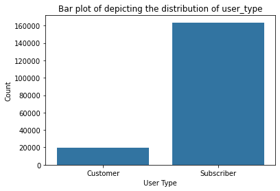

```python
# Bar plot visualization of 'user_type' column
sb.countplot(data=df, x='user_type', color=base_color)
label('User Type', 'Count', 'Bar plot of depicting the distribution of user_type');
```

> From the exploratory analysis, we find that the users (type of users) of Ford GoBike System are mainly customers and subscribers. Again, from the bar graph plot, Subscriber user_type recored the highest frequency count, followed by Customer user_type. Figuratively, Subscriber user_type and Customer user_type recorded 163,544 counts and 19,868 counts respectively.

## What gender had highest usage of the service?

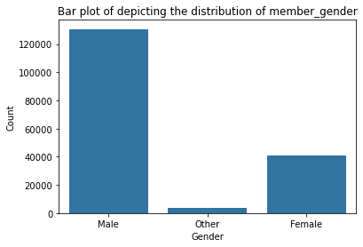

```python
# Bar plot visualization of 'member_gender' column
sb.countplot(data=df, x='member_gender',color=base_color)
label('Gender', 'Count', 'Bar plot of depicting the distribution of member_gender');
```

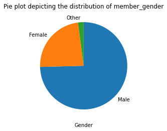

```python
# gender type of the users
sorted_counts = df_cp['member_gender'].value_counts()
plt.pie(sorted_counts, labels = sorted_counts.index, startangle = 90, counterclock = False)
label('Gender','', 'Pie plot depicting the distribution of member_gender');
```

## what is age distribution of users?

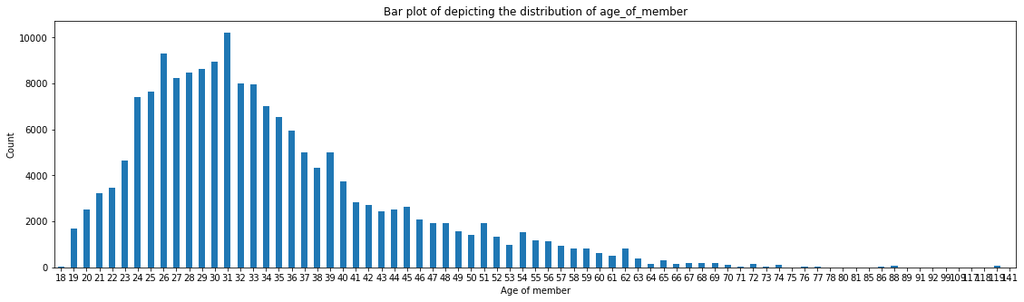

```python
# getting visualization of 'age_of_member' using matplotliib
age_of_member = df_cp['age_of_member'].value_counts().sort_index()
age_of_member.plot(kind='bar', figsize=(19,5), rot=0)
label('Age of member', 'Count', 'Bar plot of depicting the distribution of age_of_member');
```

> From the bar plot, it is age 31 is identified as the age with highest count among users, followed by ages 26, 30, 29, 28, to mention but a few respectively.

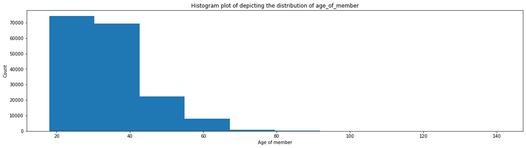

```python
#viewing the hist distribution of their ages
plt.figure(figsize=[20, 5])
plt.hist(data = df_cp, x = 'age_of_member')
label('Age of member', 'Count', 'Histogram plot of depicting the distribution of age_of_member');
```

## What is the nature of bike_share_for_all_trip

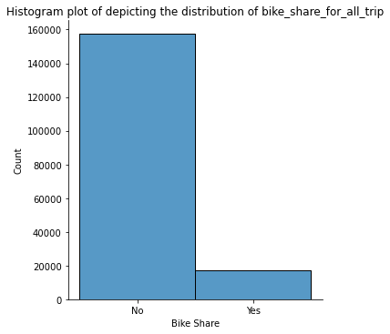

```python
#Plotting a displot to explore the this column
sb.displot(data=df_cp, x='bike_share_for_all_trip', kind='hist')
label('Bike Share', 'Count', 'Histogram plot of depicting the distribution of bike_share_for_all_trip');
```

> From the observation, `Yes` means there was sharing of bike for all trip and `No` means there was not sharing of same bike for some trips. Figuratively, No bike sharing recorded `157606 counts` and Yes also recorded `17346 counts`

### Discuss the distribution(s) of your variable(s) of interest. Were there any unusual points? Did you need to perform any transformations?

> The nature of distributions of variables **member_gender, user_type, bike_share_for_all_trip, end_station_longitude, end_station_longitude, member_birth_year** are of interest to me fopr further exploration.

### Of the features you investigated, were there any unusual distributions? Did you perform any operations on the data to tidy, adjust, or change the form of the data? If so, why did you do this?

> There was an usual distributions in `member_gender`, `member_birth_year` and `user_type`. Created a new column `age_of_member` to know the ages of the users of Bike Ford System.

## Bivariate Exploration

> In this section, investigate relationships between pairs of variables in your data. Make sure the variables that you cover here have been introduced in some fashion in the previous section (univariate exploration).

## Is there any relation between member gender and user type?

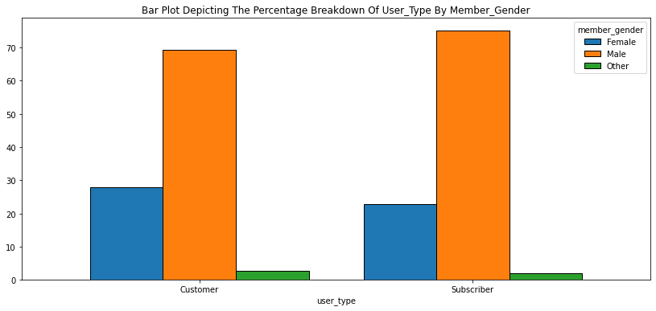

```python
df.groupby('user_type')['member_gender'].value_counts(normalize=True).unstack().mul(100).plot.bar(edgecolor='black', figsize=[14,6], rot=0, width=0.8);
plt.title('Bar plot depicting the percentage breakdown of user_type by member_gender'.title());
```

> - it can be observed that "Male" gender was the highest among both the `Subscriber` user type and `Customer` user type, followed by "Female" gender in both user types. Last but not the least, "Other Genders" placed third place among both user types.

## Nature between bikeshare and user type

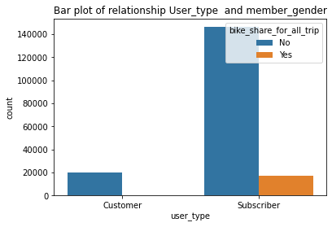

```python
sb.countplot(data = df, x = 'user_type', hue = 'bike_share_for_all_trip').set(title='Bar plot of relationship User_type  and member_gender');
```

> It was found that the relationship between the two variable (user_type and bike_share_for_all_trip) was the "no-sharing of bike for all trip" which recorded the highest count among both the customer user_type and subscriber user_type

## Distance diffrence between the user type

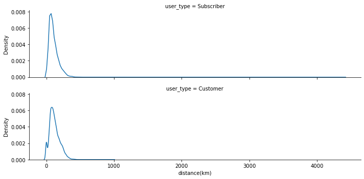

```python
#  relation between user type and distance each user_type took
ordered_type = df_cp.user_type.value_counts().index
g = sb.FacetGrid(df_cp, row="user_type", row_order=ordered_type,
                  height=2.5, aspect=4,)
g.map(sb.kdeplot, "distance(km)");
```

> From the plot above, the user type 'Subcriber' has the highest distance covered compared to the 'Customer'

```python
df_cp.user_type.value_counts()
```

```
Subscriber    158386
Customer       16566
Name: user_type, dtype: int64
```

## Is there a connection associated with gender of member and bike_share_for_all-trip?

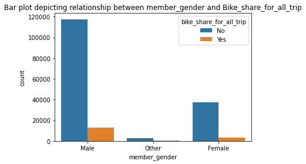

```python
sb.countplot(data = df, x = 'member_gender', hue = 'bike_share_for_all_trip').set(title='Bar plot depicting relationship between member_gender and Bike_share_for_all_trip');
```

> From the graph, there was relationship between Female gender and other gender was `the sharing of bike for all trip`. However, `no-bike-sharing` was predominately more among Male gender, female gender and Other gender respectively.

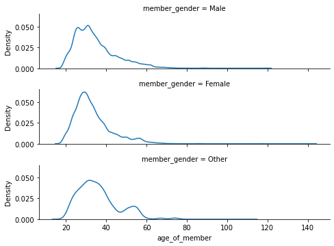

```python
# using facetgrid to plot the relations
ordered_type = df_cp.member_gender.value_counts().index
g = sb.FacetGrid(df_cp, row="member_gender", row_order=ordered_type,
                  height=1.7, aspect=4,)
g.map(sb.kdeplot, "age_of_member");
```

> - From the plots we identify that the female gender has the highest youngest age followed by male and other respectively. Since most age of the users are people ranging from 20 to 80.

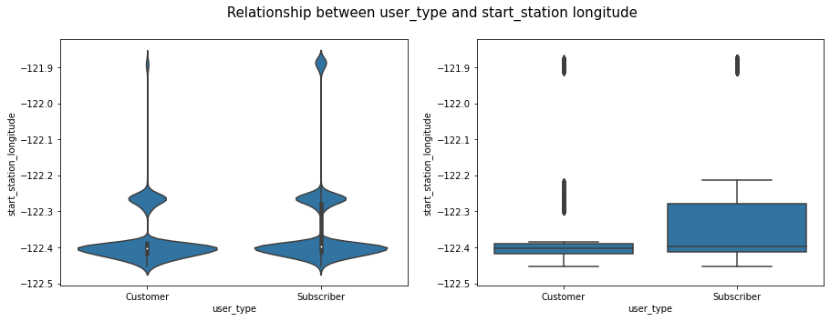

```python
# TWO PLOTS IN ONE FIGURE
plt.figure(figsize = [15, 5]).suptitle(' Relationship between user_type and start_station longitude', fontsize=15)

# LEFT plot: violin plot
plt.subplot(1, 2, 1)
#Let's return the axes object
ax1 = sb.violinplot(data=df_cp, x='user_type', y='start_station_longitude', color=base_color)
plt.xticks(rotation=0);

# RIGHT plot: box plot
plt.subplot(1, 2, 2)
ax2 = sb.boxplot(data=df_cp, x='user_type', y='start_station_longitude', color=base_color)
plt.xticks(rotation=0)
plt.ylim(ax1.get_ylim()); # set y-axis limits to be same as left plot
```

> From the violin plot, it can be observed that the interquartile range (the black bar in the center of violin) varies from customer user_type (short) to subscriber user_type (long). Again, it can also be observed the third quartile tends to be smaller and also indicates the presence of outside points.

### Talk about some of the relationships you observed in this part of the investigation. How did the feature(s) of interest vary with other features in the dataset?

> One of the relationships observed was the relationship between Female gender and other gender was the sharing of bike for all trip. However, no-bike-sharing was predominately among Male gender, female gender and Other gender respectively.In terms of population, the male gender recorded the highest counts across all other variable distribution, followed by female gender and other genders respectively.

## Multivariate Exploration

> Create plots of three or more variables to investigate your data even further. Make sure that your investigations are justified, and follow from your work in the previous sections.

## Pairgrid showing the univariate distribution of variables in the datasets

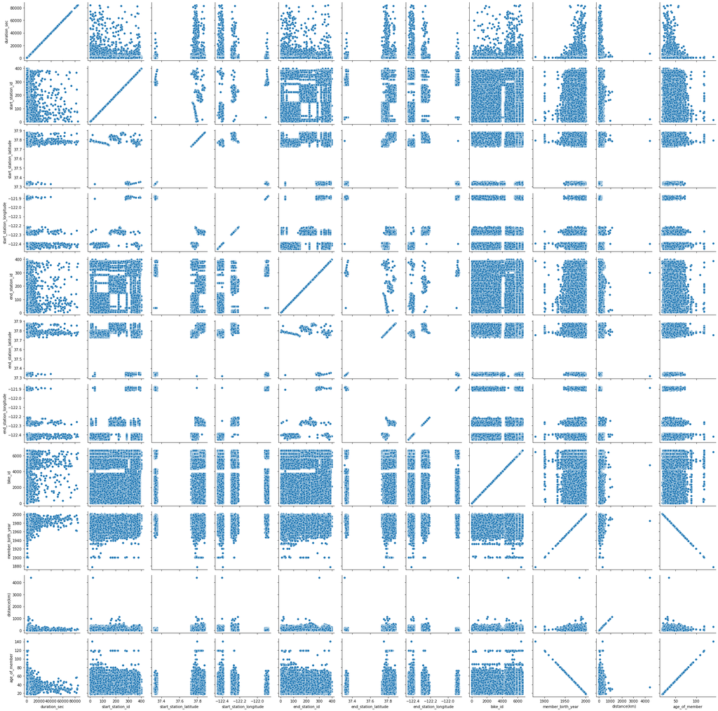

```python
# pairgrid display showing the univariate distribution of the variable in each column
g = sb.PairGrid(df_cp)
g.map(sb.scatterplot);
```

## Plot dipicting the relations between member birth year, age of member, and member gender

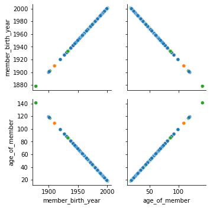

```python
#
g = sb.PairGrid(df_cp, vars=["member_birth_year", "age_of_member"], hue="member_gender")
g.map(sb.scatterplot);
```

## Conclusions

> Remove all Tips mentioned above, before you convert this notebook to PDF/HTML

> At the end of your report, make sure that you export the notebook as an html file from the `File > Download as... > HTML or PDF` menu. Make sure you keep track of where the exported file goes, so you can put it in the same folder as this notebook for project submission. Also, make sure you remove all of the quote-formatted guide notes like this one before you finish your report!

## References

- https://towardsdatascience.com/violin-plots-explained-fb1d115e023d
- https://seaborn.pydata.org/tutorial/axis_grids.html
- https://github.com/Harry6234
- https://stackoverflow.com/questions/51252580/how-to-resolve-typeerror-can-only-concatenate-str-not-int-to-str